# TD_Devoir_Simulation_Aléatoire

### EXERCICE1

#### **1.Donner le code pour acquérir les données et les visualiser.**

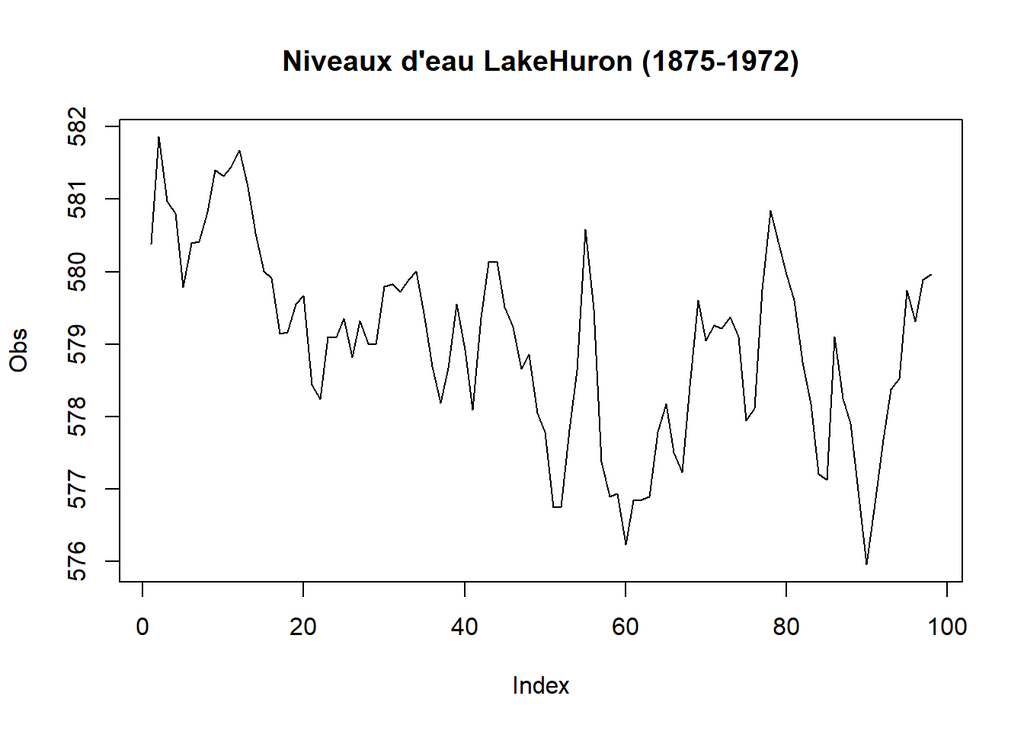

```r
#1- Code pour l'aquisition des données

Obs=as.vector(LakeHuron)



plot(Obs, type="l", main="Niveaux d'eau LakeHuron (1875-1972)")
```

#### **2. Tracer la fonction de répartition empirique.**

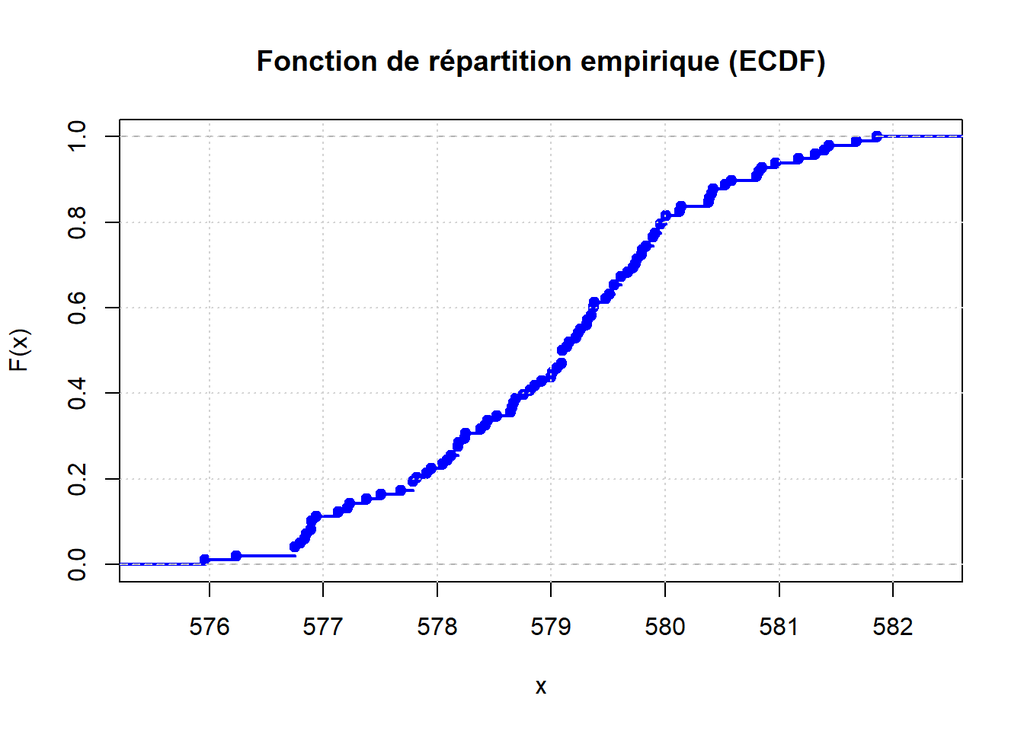

```r
#2 Tracons la fonction empirique
Fonction_empirique <- ecdf(Obs)
 # Tracé
plot(Fonction_empirique, main = "Fonction de répartition empirique (ECDF)",xlab = "x", ylab = "F(x)", col = "blue", lwd = 2)

grid()
```

#### 3**. Ajouter sur ce graphique la fonction de répartition de la loi normale dont l’espérance et l’écart-type sont la moyenne et l’écart-type de la variable Obs.**

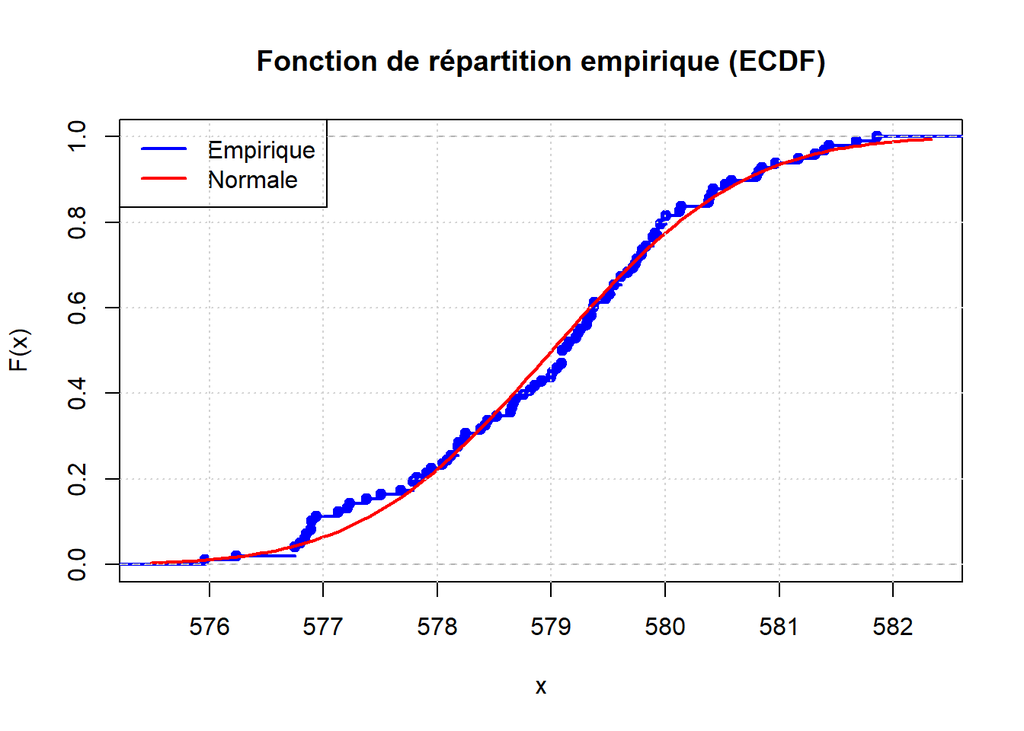

```r
#3 Ajoute la fonction de répartition de la loi normale de moyenne et d'ecart type celle de Obs


#Moyenne et ecart type

mu=mean(Obs)

ecart_type=sd(Obs)


y=pnorm(Obs,mu,ecart_type)



plot(Fonction_empirique, main = "Fonction de répartition empirique (ECDF)",
xlab = "x", ylab = "F(x)", col = "blue", lwd = 2)

curve(pnorm(x, mu, sd=ecart_type), col="red", lwd=2, add=TRUE)

legend("topleft", legend=c("Empirique", "Normale"),
       col=c("blue", "red"), lwd=2)

#FONCTION DE REPARTITION



grid()
```

#### **4. Tracer la fonction de quantile empirique.**

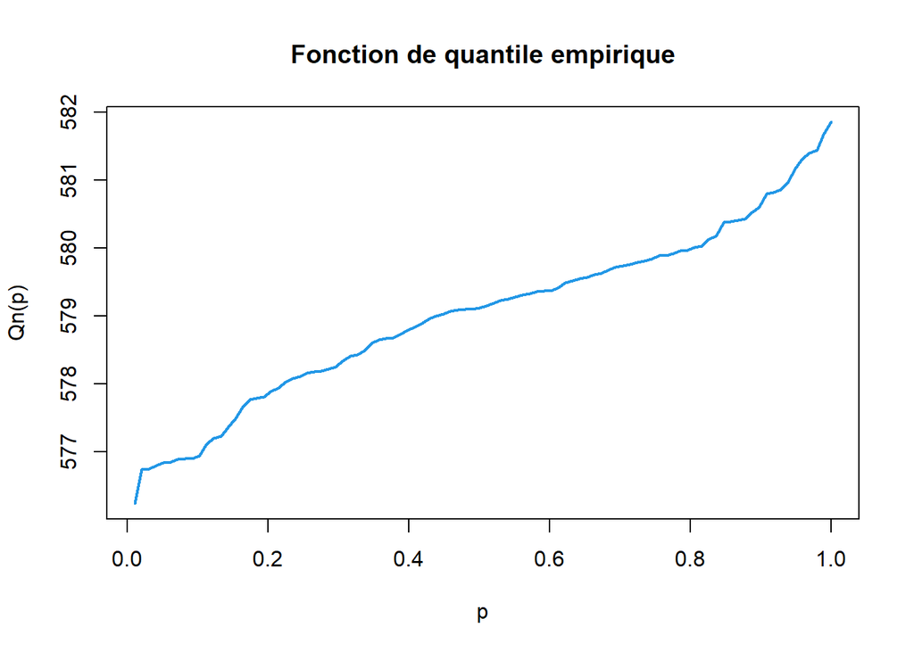

```r
#Fonction de quantile


N=length(sort(Obs))

ptx = seq(from=1/N, to=1,by=1/N)

Qn = quantile(Obs, ptx)

plot(ptx, Qn, type='l', xlab="p",ylab="Qn(p)", main="Fonction de quantile empirique", col=4,
lwd= 2)
```

#### <sup>**5-Tracer le QQ-plot de la variable Obs.**</sup>

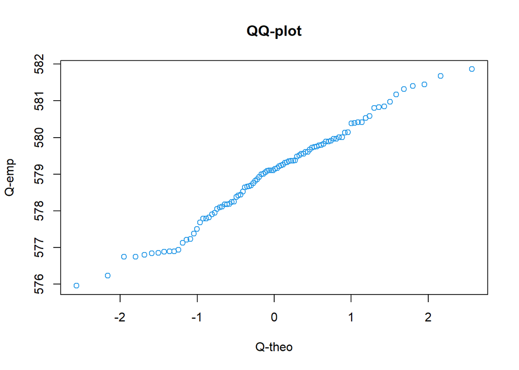

```r
#QQ-plot
qqnorm(Obs, xlab="Q-theo", ylab="Q-emp", col=4, main="QQ-plot")
```

#### <sup>**6-Tracer l’histogramme de la variable Obs ainsi que la densité de la loi normale dont l’espérance et l’écart-type sont la moyenne et l’écart-type de la variable Obs.**</sup>

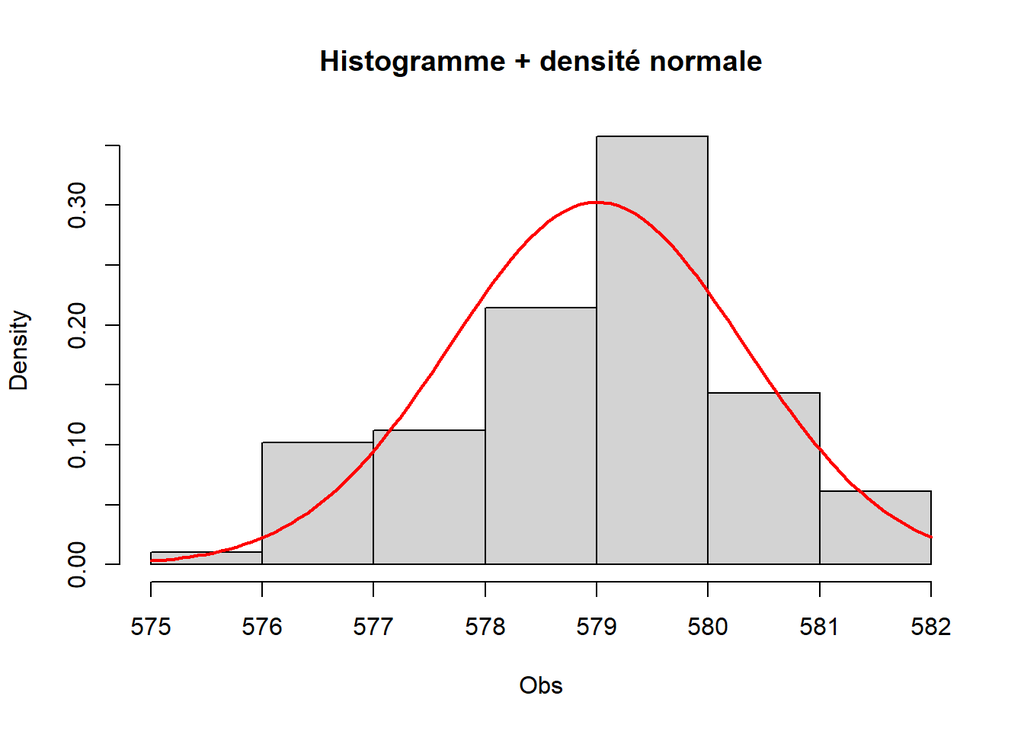

```r
hist(Obs, prob=T,col="lightgray",main="Histogramme + densité normale")
#Densité normale

curve(dnorm(x, mu, ecart_type), col="red", lwd=2, add=TRUE)
```

#### <sup>**7.Calculer puis représenter un estimateur à noyau de la densité.**</sup>

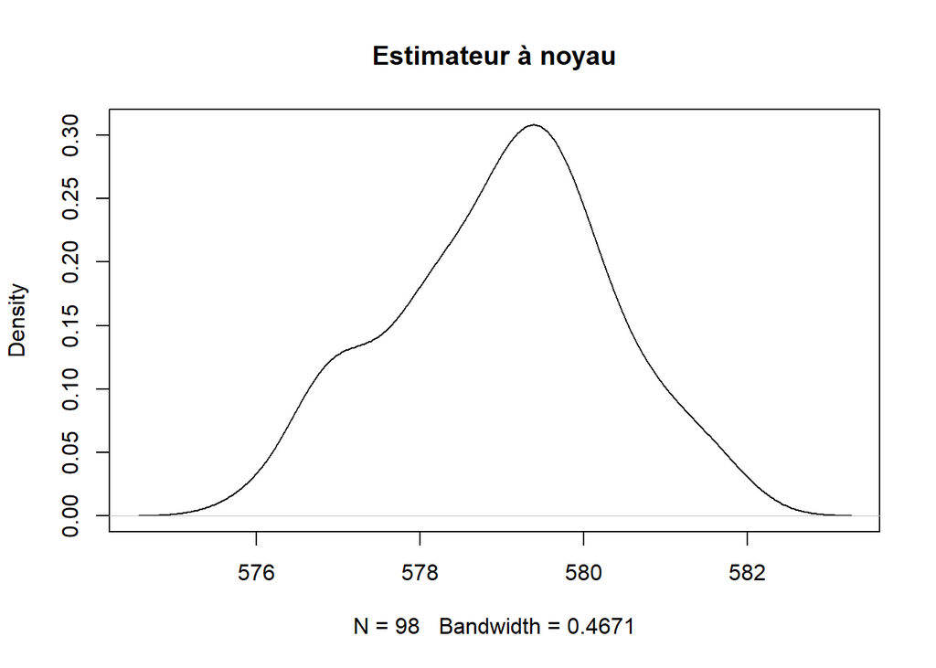

```r
dens <- density(Obs)  #Calcul

plot(dens, main="Estimateur à noyau") #Répresentation
```

#### <sup>**-Quel est le noyau utilisé ?**</sup>

Le noyau de la densité utilisé est le noyau gaussien

#### <sup>**-Quelle est la fenêtre utilisée ?**</sup>

```r
#fenetre utilise
dens$bw
```

```
## [1] 0.4671343
```

**La fenêtre utilisé est** :

```
0.4671343
```

#### <sup>**-Tracer dans une même fenêtre plusieurs estimateurs à noyau.**</sup>

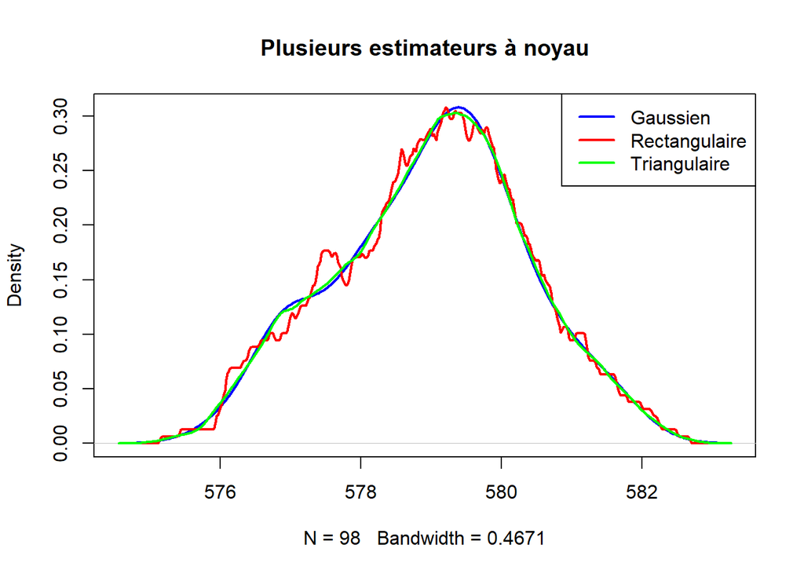

```r
dens_gauss <- density(Obs, kernel="gaussian")
dens_rect  <- density(Obs, kernel="rectangular")
dens_tri   <- density(Obs, kernel="triangular")

plot(dens_gauss, col="blue", lwd=2, main="Plusieurs estimateurs à noyau")

lines(dens_rect,  col="red", lwd=2)

lines(dens_tri,   col="green", lwd=2)

legend("topright", legend=c("Gaussien","Rectangulaire","Triangulaire"),
       col=c("blue","red","green"), lwd=2)
```

## <sup>EXERCICE2</sup>

#### **Utilisons la méthode bootstrap pour déterminer intervalle de confiance à 95 % des moyennes échantillonnales pour différentes valeurs de B**

```r
library(boot)
# Données
x <- c(51, 45, 49, 66, 53, 41, 58, 56, 60, 63, 75, 89, 73, 84, 66, 85, 73, 71, 78, 65)

set.seed(123)
fct <- function(data, i) mean(data[i]) # Bootstrap
```

```r
 #  Intervalle par la Methode bootstrap pour B=50

b1 <- boot(x, fct, R = 50)
boot.ci(b1)
```

```
## BOOTSTRAP CONFIDENCE INTERVAL CALCULATIONS
## Based on 50 bootstrap replicates
##
## CALL :
## boot.ci(boot.out = b1)
##
## Intervals :
## Level      Normal              Basic
## 95%   (59.67, 70.20 )   (59.85, 72.39 )
##
## Level     Percentile            BCa
## 95%   (57.71, 70.25 )   (56.80, 69.44 )
## Calculations and Intervals on Original Scale
## Some basic intervals may be unstable
## Some percentile intervals may be unstable
## Warning : BCa Intervals used Extreme Quantiles
## Some BCa intervals may be unstable
```

```r
 # Intervalle par la Methode bootstrap pour B=200

b2 <- boot(x, fct, R = 200)
Intervalle_confiance2 <-boot.ci(b2)
Intervalle_confiance2
```

```
## BOOTSTRAP CONFIDENCE INTERVAL CALCULATIONS
## Based on 200 bootstrap replicates
##
## CALL :
## boot.ci(boot.out = b2)
##
## Intervals :
## Level      Normal              Basic
## 95%   (59.04, 70.69 )   (58.41, 70.24 )
##
## Level     Percentile            BCa
## 95%   (59.86, 71.69 )   (59.66, 71.45 )
## Calculations and Intervals on Original Scale
## Some basic intervals may be unstable
## Some percentile intervals may be unstable
## Some BCa intervals may be unstable
```

```r
 # Intervalle par la Methode bootstrap pour B=1000

b3 <- boot(x, fct, R = 1000)
Intervalle_confiance3 <-boot.ci(b3)
Intervalle_confiance3
```

```
## BOOTSTRAP CONFIDENCE INTERVAL CALCULATIONS
## Based on 1000 bootstrap replicates
##
## CALL :
## boot.ci(boot.out = b3)
##
## Intervals :
## Level      Normal              Basic
## 95%   (59.40, 70.78 )   (59.85, 71.35 )
##
## Level     Percentile            BCa
## 95%   (58.75, 70.25 )   (58.55, 70.10 )
## Calculations and Intervals on Original Scale
```

```r
 #Intervalle par la Methode bootstrap pour B=2000

b4 <- boot(x, fct, R = 2000)
Intervalle_confiance4 <-boot.ci(b4)
Intervalle_confiance4
```

```
## BOOTSTRAP CONFIDENCE INTERVAL CALCULATIONS
## Based on 2000 bootstrap replicates
##
## CALL :
## boot.ci(boot.out = b4)
##
## Intervals :
## Level      Normal              Basic
## 95%   (59.33, 71.02 )   (59.25, 71.15 )
##
## Level     Percentile            BCa
## 95%   (58.95, 70.85 )   (59.15, 70.90 )
## Calculations and Intervals on Original Scale
```

**Conclusion:**

Pour B=50

Intervalle de confiance: **[59.67, 70.20 ]**

## <sup>EXERCICE3</sup>

### <sup>1-Tracer la fonction de répartition empirique.</sup>

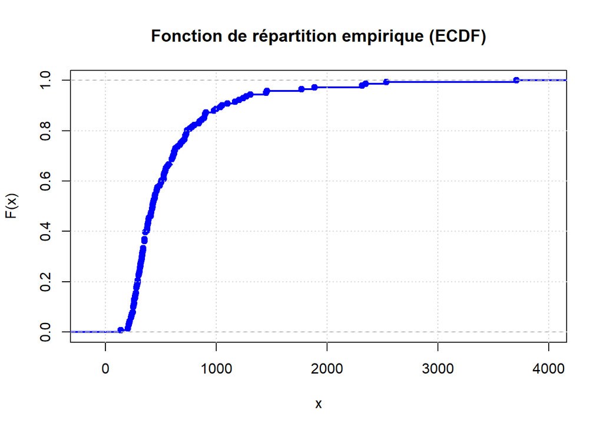

```r
#1- Code pour l'aquisition des données

data2=as.vector(rivers)
Obs1=sort(data2)

#2 Tracons la fonction empirique
Fonction_empirique2 <- ecdf(Obs1)
 # Tracé
plot(Fonction_empirique2, main = "Fonction de répartition empirique (ECDF)",
xlab = "x", ylab = "F(x)", col = "blue", lwd = 2)

grid()
```

### <sup>2-Superposer la fonction de répartition de la loi normale.</sup>

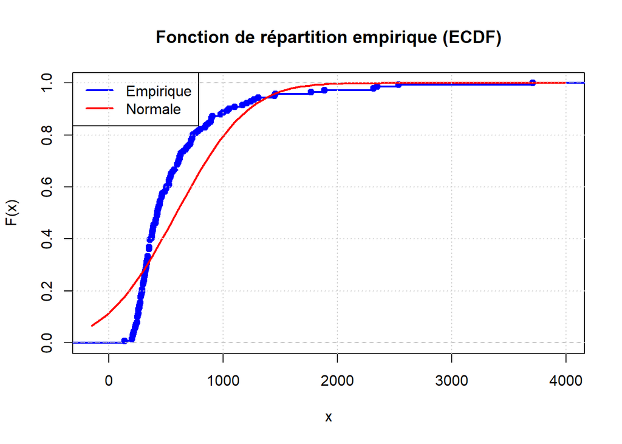

```r
#2 Ajoute la fonction de répartition de la loi normale de moyenne et d'ecart type celle de Obs


#Moyenne et ecart type

mu1=mean(Obs1)

ecart_type1=sd(Obs1)


plot(Fonction_empirique2, main = "Fonction de répartition empirique (ECDF)", xlab = "x", ylab = "F(x)", col = "blue", lwd = 2)


#FONCTION DE REPARTITION


curve(pnorm(x,mean=mu1,sd=ecart_type1),col = "red", lwd = 2,add=TRUE)

legend("topleft", legend=c("Empirique", "Normale"),
       col=c("blue", "red"), lwd=2)


grid()
```

### <sup>3- Faire un test d’ajustement de Kolmogorov-Smirnov et Shapiro-Wilks.</sup>

### <sup>Peut-on considérer que les données *rivers* sont distribuées selon une loi normale ?</sup>

### <sup>Hypothèse du test de kolmogorov</sup>

Soit F la fonction de répartition de notre variable Obs1 représentatif de rivers

$H_o:F=F_o$

$H_1:F \neq F_o$

**Code**

```r
Obs1=data2
#test de kolmogorov simrov
ks.test(Obs1, "pnorm", mean = mu1, sd = ecart_type1)
```

```
##
##  Asymptotic one-sample Kolmogorov-Smirnov test
##
## data:  Obs1
## D = 0.20825, p-value = 9.768e-06
## alternative hypothesis: two-sided
```

<sup>**Resultats**</sup>

```
Asymptotic one-sample Kolmogorov-Smirnov test  data:  Obs1 D = 0.20825, p-value = 9.768e-06 alternative hypothesis: two-sided
```

### <sup>Hypothèse du test de shapiro</sup>

$H_o:$ la variable Obs1 suit une loi normale

$H_1:$ la variable Obs1 ne suit pas une loi normale

**Code**

```r
Obs1=data2
#test de shapiro
shapiro.test(Obs1)
```

```
##
##  Shapiro-Wilk normality test
##
## data:  Obs1
## W = 0.66662, p-value < 2.2e-16
```

<sup>**Resultats**</sup>

```
Shapiro-Wilk normality test  data:  Obs1 W = 0.66662, p-value < 2.2e-16
```

Les p-value étant faible dans les deux cas en prenant $\alpha=5$% alors on rejette les hypothèse $H_o$

**On conclut donc qu’on ne peut pas considérer que les données *rivers* sont distribuées selon une loi normale**

## EXERCICE4

### **Répondons à la question en supposant une hypothèse normale des données.**

Soit $m_o$ la moyenne de l’échantillon exrait et $m_e$ celui de l’échantillon 24h après

$H_o:m_o= m_e$

$H_1:m_o < m_e$

Les variables x_apres,x_avant sont des variables appariés issus des mêmes individus

Donc il s’agit d’un test sur la moyenne de deux echantillons de variables aléatoires appariés

**Code**

```r
#Données
x_avant=c(12000,13000,21500,17000,15000,22000,11000,21000)

x_apres=c(11000,20000,31000,28000,26000,30000,16000,29000)


# Test

t.test(x_apres,x_avant,paired="TRUE")
```

```
##
##  Paired t-test
##
## data:  x_apres and x_avant
## t = 5.2786, df = 7, p-value = 0.00115
## alternative hypothesis: true mean difference is not equal to 0
## 95 percent confidence interval:
##   4036.762 10588.238
## sample estimates:
## mean difference
##          7312.5
```

**Conclusion**

```
p-value = 0.00115
La p-value = 0.00115 <0.05 donc on rejette l'hypothèse intiale
```

Par conséquent l’hypothèse $H_1$ est retenue .

Il existe donc un accroissement significatif du nombre de bactéries par cm<sup>3</sup> au cours du temps

### **Répondons à la question par un test du signe.**

```r
# Médiane hypothétique

mediane_theorique <- mean(x_avant)

# On compte les signes

plus <- sum(x_apres> mediane_theorique)

moins <- sum(x_apres < mediane_theorique)

n <- plus + moins  # On ignore les valeurs égales à la médiane

# Test du signe unilatéral

binom.test(plus, n = n, p = 0.5, alternative = "greater")
```

```
##
##  Exact binomial test
##
## data:  plus and n
## number of successes = 6, number of trials = 8, p-value = 0.1445
## alternative hypothesis: true probability of success is greater than 0.5
## 95 percent confidence interval:
##  0.4003106 1.0000000
## sample estimates:
## probability of success
##                   0.75
```

#### **Conclusion:**

```r
# Test de Wilcoxon-Mann-Whitney (non paramétrique)


wilcox.test(x_apres,x_avant,alternative = "greater", paired = TRUE)
```

```
##
##  Wilcoxon signed rank test with continuity correction
##
## data:  x_apres and x_avant
## V = 35, p-value = 0.01028
## alternative hypothesis: true location shift is greater than 0
```

**Conclusion**

```
p-value = 0.01028

La p-value < 0.05 donc on rejette l'hypothèse Ho
```

Par conséquent on retient que $H_1$ est vrai donc il existe un accroissement significatif du nombre de bactéries par cm<sup>3</sup>

au cours du temps.